# Act_Report

### Visualization

After storing the clean data. I proceeded to put the data through exploratory data analysis in order to derive insights and conclusions using the data

**a)**

Using `df.describe()` I displayed a statisitcal summary of all the numeric data

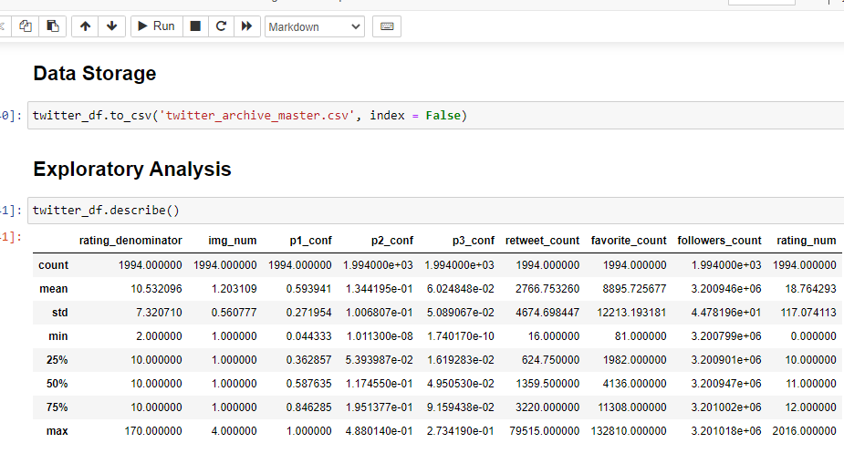

**b)**

To view the trend of retweets of WeRateDogs posts over the years. The following was done:

1. The years were extracted from the 'timestamp' column into a new column named 'year'
2. a bar plot was plotted to visually represent the trend

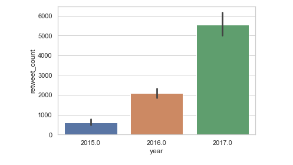

**c)**

To view the trend of favorite counts of WeRateDogs posts over the years a bar plot was plotted to visually represent the trend

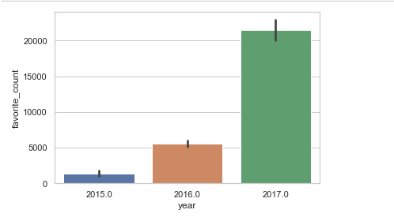

**d)**

To view how the followers count faired over the months a line plot was used to display the monthly trend of followers count

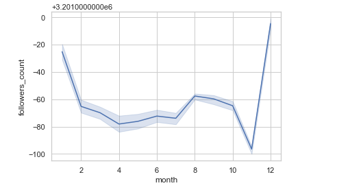

**e)**

In the final exploration, the dog categories (doggo, floofer, pupper and puppo) were analysed to determine the most frequently posted category. Using a bar plot, the categories were displayed and assessed.

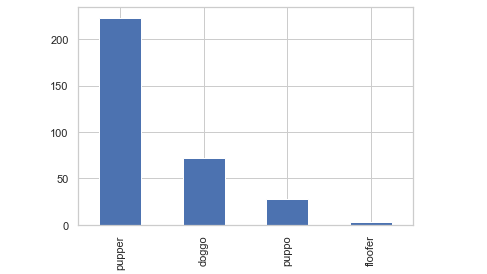